# Climate HAzard Toolbox (CHAT)

Flexible and semi-automatic approach to access and visualize CORDEX-CORE climate models

true  
February 15, 2022

## Setting the scene

This document is intended to be used internally to define how to use the Hub and the figure captions to use in climate risk assessments and rationales.

The Hub is made of 4 main functions:

1. **load_data**: used to load CORDEX-CORE models of a region of interest. The whole year is loaded as dafault
2. **climate_change_signal**: used to visualize climate change signal and agreement in the sign of the climate change signal calculated as described by the IPCC
3. **proj**: used to visualize future projections. Bias-correction can be performed automatically as well as trend analysis
4. **hist**: used to visualize historical data (W5e5) (Cucchi et al. 2020). Trend analysis can be performed

## Case study: Kenya

We provide an example of the figures that can be produced from the Hub and the figure captions to use when writing climate climate risk assessments. The below figures refer to season **Jan-March**.

## load_data function

The load_data function allows the user to load data for a particular country or region of interest. This step takes up to 15 minutes for big countries.

`load_data(country, xlim, ylim, domain)`

## climate_change_signal function

This function allows the user to look at model agreement in the sign of the climate change signal (as defined by the IPCC) as well as the mean of climate change signal (average deviation from historical period) and standard deviation of the climate change signal (between models standard deviation). When precipitation is selected (var=“pr), values refer to annual total precipitation while when temperature variables are selected (”tasmax" or “tasmin”), mean annual temperature is considered. When a threshold argument is specified, then climate change signal refers to number of days. For example, average number of days in which precipitation was lower than 1 mm compared to baseline in a 30 year time frame. This function has several arguments.

`climate_change_signal(data, save, plot_name, season, lowert, uppert, int_month, palette)`

1. **save**: logical. Used to save or not the plots
2. **plot_name**: Character.Specify the name of the plot
3. **season**: numerical. Season of interest
4. **lowert**: numerical. Lower threshold
5. **uppert**: numerical. Upper threshold
6. **int_month**: Numerical. Automatic plotting by season. Can either take 6 or 3
7. **palette**: character. User specified color palette

#### Thresholds are not specified

The example below is when threshold are not defined. In this case:

`climate_change_signal(data_out, save=TRUE, plot_name="Kenya", season=1:3)`

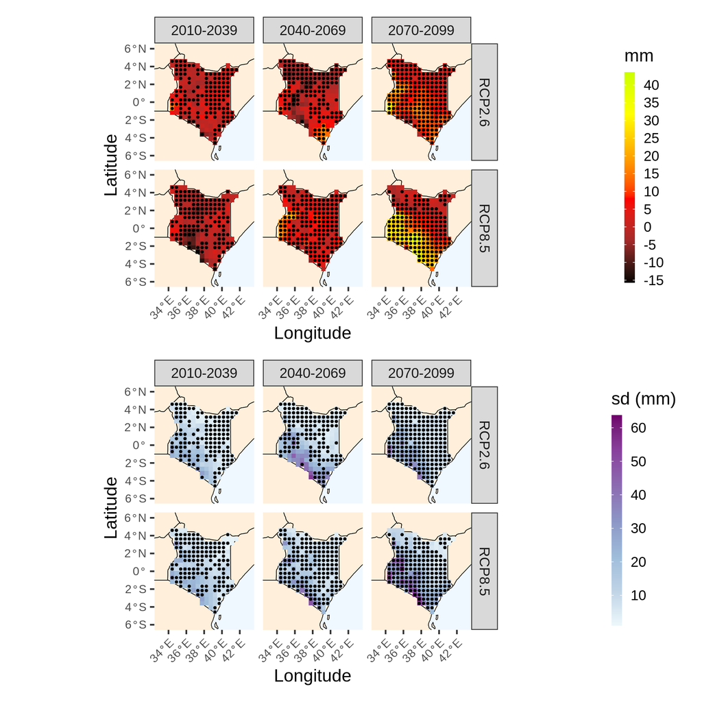

Fig.1. Mean and standard deviation of the climate change signal for precipitation in Kenya, January-March. The first plot indicates the overall difference in total annual precipitation (average of 6 CORDEX-CORE models) from historical period (1976-2005). The black dot indicates whether at least 60% of the models agree in the sign of the climate change signal (positive or negative). The second plot shows the average annual standard deviation in the climate change signal calculated from the 6 CORDEX-CORE models. Figure produced with the Climate HAzard toolbox (CHAT) developed at FAO (Climate risk team)

#### Thresholds are specified

We now look at the climate change signal in the number of dry days (precipitation < 1 mm)

`climate_change_signal(data_out, save=TRUE, plot_name="Kenya", lowert=1, season=1:3)`

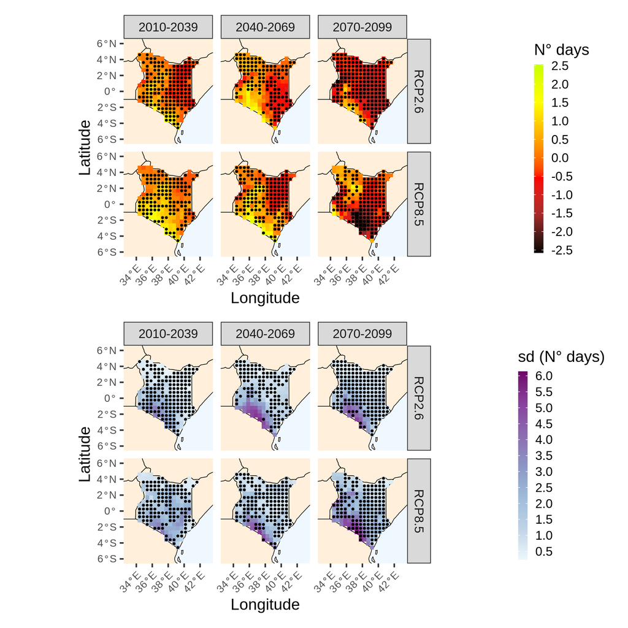

Fig.2. Mean and standard deviation of the climate change signal for annual dry days in Kenya (days with less than 1 mm of rain), January-March. The first plot indicates the annual average difference in dry days (average of 6 CORDEX-CORE models) from historical period (1976-2005). The black dot indicates whether at least 60% of the models agree in the sign of the climate change signal (positive or negative). The second plot show the average annual standard deviation in the climate change signal for dry days from 6 CORDEX-CORE models. Figure produced with the Climate HAzard toolbox (CHAT) developed at FAO (Climate Risks Team)

## proj function

This function is used to look at climate projections. It includes the option to bias-correct the data with the scaling method. If threshold are not specified, results are cumulative (in case of precipitation) or averages (in case of temperatures). The option trends allows the user to see the results of linear regression applied to yearly value for each pixel, time-frame and RCP. When both thresholds and trends are specified, linear regression is applied to the total number of days per season in which a certain threshold was or was not exceeded. The results for each model are averaged before visualization, thus an ensemble mean is computed after applying for each model the specified operations. For example, if bias.correction is set to TRUE and uppert is specified, first bias correction is applied to each model, then the number of days exceeding uppert are calculated and lastly the ensemble mean is performed.

`proj(data, save, plot_name, season, lowert, uppert, int_month, trends, palette, bias.correction)`

1. **save**: logical. Used to save or not the plots
2. **plot_name**: character. Specify the name of the plot
3. **season**: numerical. Season of interest
4. **lowert**: numerical. Lower threshold
5. **uppert**: numerical. Upper threshold
6. **int_month**: numerical. Automaic plotting by season. Can either take 6 or 3
7. **trends**: logical. Apply linear regression or not
8. **bias.correction**: logical
9. **palette**: character. User specified color palette

#### thresholds and trends are not specified

`proj(data_out, save=TRUE, plot_name="Kenya_proj", trends=FALSE, seaosn=1:3)`

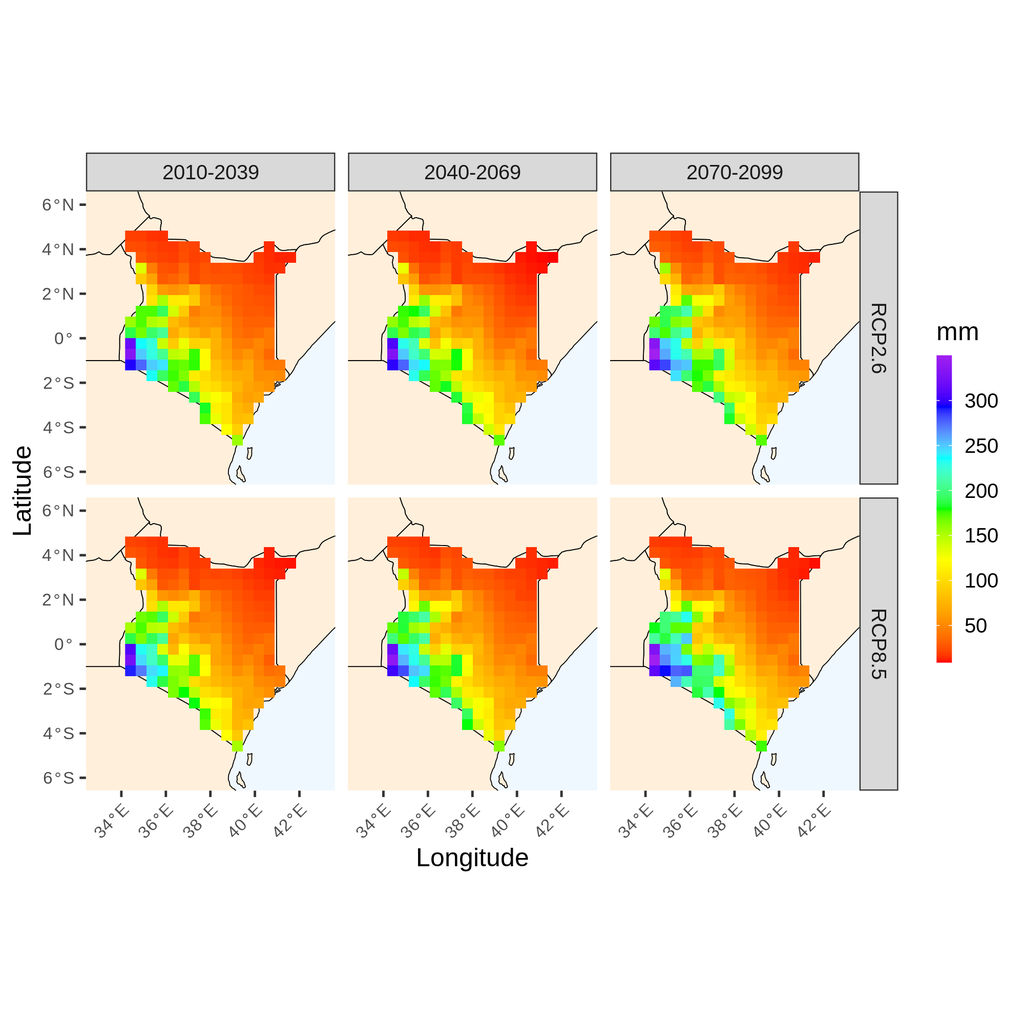

Fig.3. Total annual precipitation in Kenya, January-March. Values are taken from a multi-model ensemble mean (average of 6 CORDEX-CORE models). Figure produced with the Climate HAzard toolbox (CHAT) developed at FAO (Climate Risks Team).

We now perform bias correction

`proj(data_out, save=TRUE, plot_name="Kenya_proj", trends=FALSE, bias.correction=TRUE)`

[figure not shown]

Fig.4. Total annual precipitation in Kenya, January-March after bias-correction. Each CORDEX-CORE model is bias corrected against w5e5 dataset and then an ensemble mean of bias corrected models is calculated and visualized. Figure produced with the Climate HAzard toolbox (CHAT) developed at FAO (Climate Risk Team).

#### trends is set as TRUE but thresholds are not specified

In this case we would be looking at the yearly increase in precipitation and whether that increase is significant or not.

`proj(data_out, save=TRUE, plot_name="Kenya_proj", trends=TRUE, bias.correction=FALSE)`

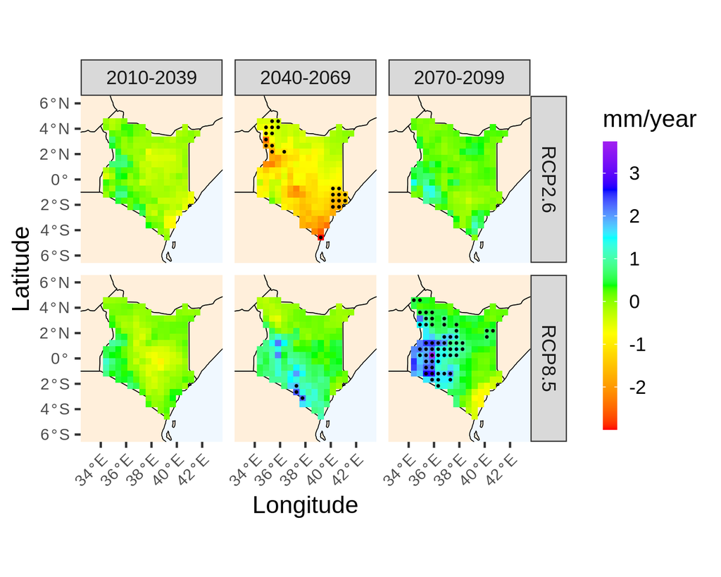

Fig.5. Yearly increase in total precipitation in Kenya, January-March. Linear regression is applied to each pixel using the total precipitation fell in the specified season per year. Thus, values refer to yearly increase in precipitation and wheter the increase is statistical significant (black dot) or not (absence of black dot). The multi-model ensemble mean (average of 6 CORDEX-CORE models) is used. Figure produced with the Climate HAzard toolbox (CHAT) developed at FAO (Climate Risk Team).

#### trends is set as TRUE and thresholds are specified

`proj(data_out, save=TRUE, plot_name="Kenya_proj", trends=TRUE, bias.correction=FALSE, lowert=1)`

In this case we would be looking at the yearly increase in number of days in which there was less than 1 mm of rain.

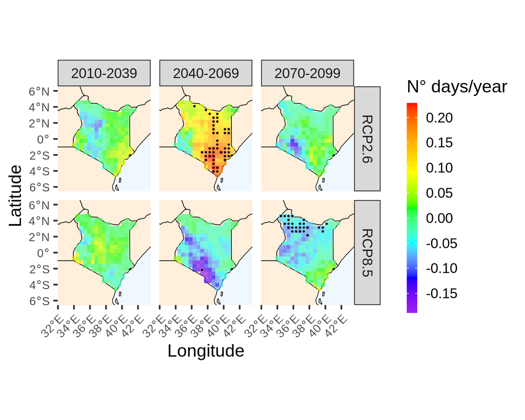

Fig.6. Yearly increase in total number of dry days in Kenya, January-March. Linear regression is applied to each pixel using the total number of days per year (specified season) with less than 1 mm of rain. Thus, values refer to yearly increase in number of dray days and wheter the increase is statistical significant (black dot) or not (absence of black dot). The multi-model ensemble mean (average of 6 CORDEX-CORE models) is used. Figure produced with the Climate HAzard toolbox (CHAT) developed at FAO (Climate Risk Team).

## hist function

The historical function visualizes data from the W5e5 dataset (Cucchi et al. 2020), which is an observational dataset giving highly accurate past climatic data information. Similar to the proj function the hist function allows the user to look at trends.

`proj(data, save, plot_name, season, lowert, uppert, int_month, trends, palette)`

1. **save**: logical. Used to save or not the plots
2. **plot_name**: character. Specify the name of the plot
3. **season**: numerical. Season of interest
4. **lowert**: numerical. Lower threshold
5. **uppert**: numerical. Upper threshold
6. **int_month**: numerical. Automaic plotting by season. Can either take 6 or 3
7. **trends**: logical. Apply linear regression or not
8. **palette**: character. User specified color palette

#### thresholds and trends are not specified

`hist(data_out, save=TRUE, trends=FALSE, season=1:3)`

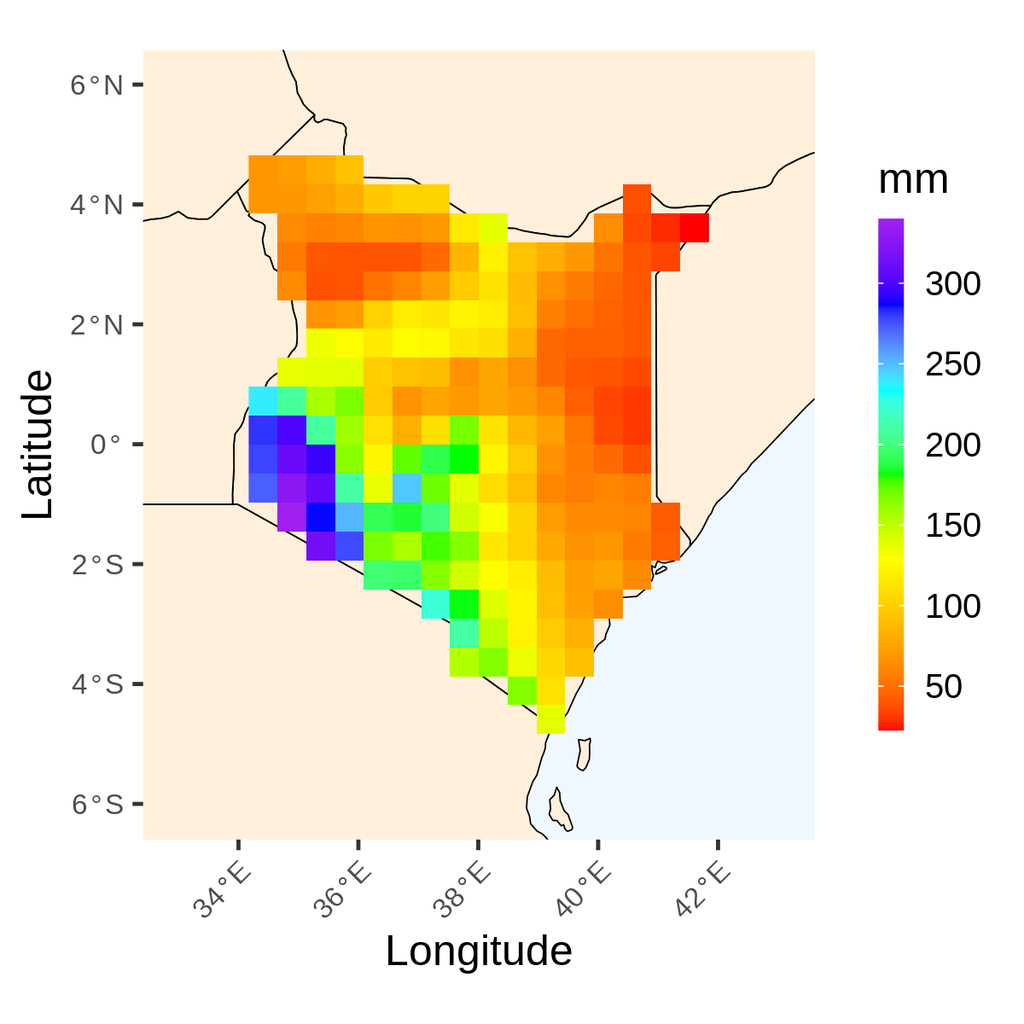

Fig.7. Total annual precipitation in Kenya, January-March (1980-2005) using the w5e5 reanalysis dataset. Figure produced with the Climate HAzard toolbox (CHAT) developed at FAO (Climate Risk Team).

#### trends is set as TRUE but thresholds are not specified

`hist(data_out, save=TRUE, trends=TRUE, season=1:3)`

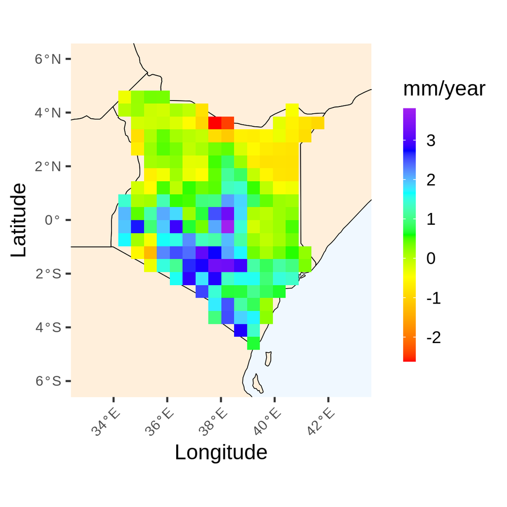

Fig.8. Yearly increase in total precipitation in Kenya, January-March (1980-2005) using the w5e5 reanalysis dataset. Linear regression is applied to each pixel using the total precipitation fell in the specified season per year. Thus, values refer to yearly increase in total precipitation and wheter the increase is statistical significant (black dot) or not (absence of black dot). Figure produced with the Climate HAzard toolbox (CHAT) developed at FAO (Climate Risk Team).

#### trends is set as TRUE and threshold are specified

`hist(data_out, save=TRUE, trends=TRUE, lowert=1, season=1:3)`

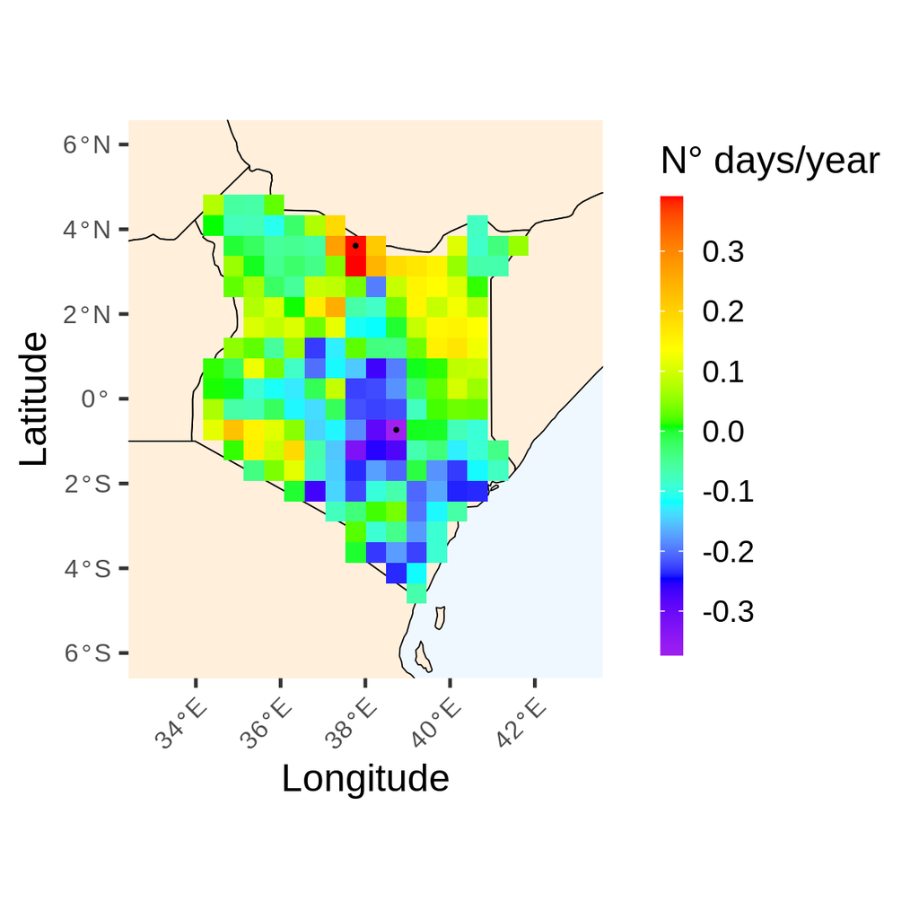

Fig.9. Yearly increase in total number of dry days in Kenya, January-March (1980-2005) using the w5e5 reanalysis dataset. Linear regression is applied to each pixel using the total number of days per year (specified season) with less than 1 mm of rain. Thus, values refer to yearly increase in number of dray days and wheter the increase is statistical significant (black dot) or not (absence of black dot). Figure produced with the Climate HAzard toolbox (CHAT) developed at FAO (Climate Risk Team).

Cucchi, Marco, Graham P. Weedon, Alessandro Amici, Nicolas Bellouin, Stefan Lange, Hannes Müller Schmied, Hans Hersbach, and Carlo Buontempo. 2020. “Wfde5: Bias-Adjusted Era5 Reanalysis Data for Impact Studies.” *Earth System Science Data* 12 (3): 2097–2120. https://doi.org/10.5194/essd-12-2097-2020.